# Statistical Modelling II

Mauricio Garcia Tec

$$\DeclareMathOperator{\N}{N}
\DeclareMathOperator{\Gam}{Gamma}
\DeclareMathOperator{\Wish}{Wishart}
\DeclareMathOperator{\tr}{tr}
\DeclareMathOperator{\Po}{Poisson}
\DeclareMathOperator{\Prob}{P}
\DeclareMathOperator{\cov}{Cov}
\newcommand{\D}[1]{\mathrm{#1}}$$

[Return to main Index](https://github.com/mauriciogtec/statsmodelling2)

# Section 4: Gaussian Processes

## Non-linear functions

### Regression view

So far, we’ve assumed our latent function is a linear function of our data – which is obviously limiting. One way of circumventing this is to project our inputs into some high-dimensional space using a set of basis functions $\phi:\mathbb{R}^d\rightarrow \mathbb{R}^N$, and then performing linear regression in that space, so that

$$y_i = \phi(x)^T\beta + \epsilon_i$$

For example, we could project $x$ into the space of powers of $x$, i.e. $\phi(x) = (1,x,x^2,x^3\dots)$ to obtain polynomial regression.

### Exercise 1

Let $\mathbf{y}$ and $\mathbf{X}$ be set of observations and corresponding covariates, and $y_*$ be the unknown value we wish to predict at covariate $\mathbf{x}_*$. Assume that
$$\begin{aligned}
\beta \sim& \mbox{N}\left(0,\Sigma\right)\\
\begin{bmatrix}f_* \\ \mathbf{f}\end{bmatrix} =& \begin{bmatrix}\boldsymbol{\phi}_*'\\ \boldsymbol{\Phi'}\end{bmatrix}\beta\\
\begin{bmatrix}y_* \\ \mathbf{y}\end{bmatrix} \sim& \mbox{N}\left(\begin{bmatrix}f_* \\ \mathbf{f}\end{bmatrix},\sigma^2\mathbf{I}\right)
\end{aligned}$$
where $\boldsymbol{\phi}:=\phi(\mathbf{x})$ and $\boldsymbol{\Phi}:=\phi(\mathbf{X})$. What is the predictive distribution $p(f_*|\mathbf{y},\mathbf{x}_*,\mathbf{X})$? Note: this is very similar to questions we did in Section 1.

*Solution*. Out model matrix is $\Phi'$ and the new point is $\phi_*$, we can ignore the $X$ notation. The posterior predictive distribution from a linear regression is
$$p(\beta \mid y, \Phi) = N\left(\beta \;\bigg\vert\; (\Phi\Phi' + \sigma^2\Sigma^{-1})^{-1}\Phi y, \frac{1}{\sigma^2}(\Phi \Phi' + \Sigma^{-1})^{-1}\right)$$
Note that $f_* = \phi_* \beta$. Hence $f_*$ is also Gaussian and

$$E(f_* \mid y, \Phi, \phi_*) = \phi_*'(\Phi'\Phi + \sigma^2\Sigma^{-1})^{-1}\Phi y$$
and
$$\mathrm{Var}(f_* \mid y, \Phi, \phi_*) = \sigma^2\phi_*'(\Phi\Phi' + \sigma^2\Sigma^{-1})^{-1}\phi_*$$

In anticipation of the next questions, we want to write everything only in terms of inner-products. Define $K = \Phi'\Sigma\Phi$ and $A = \Phi\Phi' + \sigma^2\Sigma^{-1}$, then

$$A\Sigma\Phi =(\Phi\Phi' + \sigma^2\Sigma^{-1})\Sigma\Phi = \Phi(\Phi'\Sigma\Phi + \sigma^2 I) = \Phi(K + \sigma^2 I)$$
ao $A^{-1}\Phi =\Sigma \Phi (K + \sigma^2 I)^{-1}$. Thus we can rewrite
$$E(f_* \mid y, \Phi, \phi_*) = \phi_*'\Sigma \Phi (K + \sigma^2I)^{-1}y$$
To fix an expression for the variance we will use the Sherman–Morrison–Woodbury matrix inversion formula
$$(B + UCV)^{-1} = B^{-1} - B^{-1}U(VB^{-1}U C)^{-1}VB^{-1}$$
Take $B= \sigma^2\Sigma^{-1}$, $U = \Phi$, $V =\Phi'$ and $C = I$. Then
$$A^{-1} = (B + UCV)^{-1} = \frac{1}{\sigma^2}\Sigma - \frac{1}{\sigma^2}\Sigma\Phi(K + \sigma^2 I)^{-1}\Phi'\Sigma.$$
So plugging that back into the variance we get
$$\mathrm{Var}(f_* \mid y, \Phi, \phi_*) = =\phi_*'\Sigma\phi_* - \phi_*'\Sigma\Phi(K + \sigma^2 I)^{-1}\Phi'\Sigma\phi_*.$$

Back to Index

Note that, in the solution to Exercise 1, we only ever see $\phi$ or $\Phi$ in a form such as $\Phi^T\Sigma\Phi$. We will define $k(\mathbf{x},\mathbf{x}') = \phi(\mathbf{x})^T\Sigma\phi(\mathbf{x}')$. Since $\Sigma$ is positive definite, we can write:

$$k(\mathbf{x},\mathbf{x}') = \psi(\mathbf{x})^T\psi(\mathbf{x})$$
where $\psi(\mathbf{x}) = \phi(\mathbf{x})\Sigma^{1/2}$

If (as here) we only ever access $\psi$ via this inner product, we can choose to work instead with $k(\cdot,\cdot)$. This may be very convenient if the dimensionality of $\psi(x)$ is very high (or even infinite… see later). $k(\cdot,\cdot)$ is often refered to as the kernel, and this replacement is referred to as the kernel trick.

### Exercise 2

Let’s look at a concrete example, using the old faithful dataset on $R$

Let $\phi(x) = (1,x,x^2,x^3)$. Using appropriate priors on $\beta$ and $\sigma^2$, obtain a posterior distribution over $f:=\phi(x)^T\beta$. Plot the function (with a 95% credible interval) by evaluating this on a grid of values.

```r
library(rstan)
library(tidyverse)
library(ggplot2)
```

```r
data("faithful",package="datasets")
```

```r
X <- faithful$waiting
y <- faithful$eruptions
Phi <- faithful %>%
  model.matrix(~ waiting + I(waiting^2 )+ I(waiting^3), data = .)
Phi[ ,-1] <- scale(Phi[ ,-1])
```

Here’s the code for a standard regression

```r
stan2_code <- '
data {
  int<lower=0> N;
  int<lower=0> D;
  matrix[N, D] X;
  vector[N] y;
  real<lower=0> kappa;
  real<lower=0> a;
  real<lower=0> b;
  int<lower=0> N_grid;
  matrix[N_grid, D] X_grid;
}
parameters {
  vector[D] beta;
  real<lower=0> sigma2;
}
transformed parameters {
  vector[N] mu;
  mu = X * beta;
}
model {
  sigma2 ~ inv_gamma(a, b);
  beta ~ normal(0, sqrt(sigma2 / kappa));
  for (i in 1:N)
    y[i] ~ normal(mu[i], sqrt(sigma2));
}
generated quantities {
  vector[N_grid] mu_grid;
  mu_grid = X_grid * beta;
}
'
```

```r
stan2 <- stan_model(model_code = stan2_code)
```

Create a grid

```r
summary(faithful$waiting)
```

```r
N_grid <- 100
m <- min(faithful$waiting)
M <- max(faithful$waiting)
Phi_grid <- data.frame(waiting = seq(m, M, length.out = N_grid)) %>%
   model.matrix(~ waiting + I(waiting^2 )+ I(waiting^3), data = .)
Phi_grid[ ,-1] <- scale(Phi_grid[ ,-1])
```

```r
standata2 <- list(
  N = nrow(Phi),
  D = ncol(Phi),
  X = Phi,
  y = y,
  a = 1.,
  b = 10,
  kappa = 0.1,
  N_grid = N_grid,
  X_grid = Phi_grid)
```

```r
fit2 <- sampling(
  stan2,
  data = standata2,
  iter = 1000,
  chains = 4,
  pars = c("beta", "sigma2", "mu_grid"),
  cores = 4)
```

```r
rstan::traceplot(fit2, pars = 'beta')
```

[output not shown]

Back to Index

```r
fpred <- rstan::extract(fit2, "mu_grid")[[1]]
```

```r
fdata <- data.frame(
  waiting = seq(m, M, length.out = N_grid),
  mean = colMeans(fpred),
  low95 = apply(fpred, 2, quantile, 0.025),
  up95 = apply(fpred, 2, quantile, 0.975)
)
```

```r
ggplot() +
  geom_line(aes(x = waiting, y = mean), data = fdata) +
  geom_ribbon(aes(x = waiting, ymin = low95, ymax = up95), alpha = 0.3, data = fdata) +
  geom_point(aes(x = waiting, y = eruptions), col = "blue", data = faithful) +
  ylab("eruptions") + ggtitle("Cubic polynomial fit")
```

[output not shown]

### Function space view

Look back at the plot from Exercise 2. We specified a prior distribution over regression parameters, which we can use to obtain a posterior distribution over those regression parameters. But, what we calculated (and plotted) was a posterior distribution over *functions*. Similarly, we can think of our prior on $\beta$ as specifying a prior distribution on the space of cubic functions. Evaluated at a finite number of input locations – as you did in Exercise 2 – this posterior distribution is multivariate Gaussian. This is in fact the definition of a Gaussian process: A distribution over functions, such that the marginal distribution evaluated at any finite set of points is multivariate Gaussian.

A priori, the covariance of $f$ is given by
$$\cov(x,x') = E[(f(x)-m(x))(f(x^T)-m(x^T))] = k(x,x')$$
. For this reason, our kernel $k$ is often referred to as the covariance function (note, it is a function since we can evaluate it for any pairs $x,x'$). In the above example, where $\beta$ had zero mean, the mean of $f$ is zero; more generally, we will assume some mean function $m(x)$.

Rather than putting a prior distribution over $\beta$, we can specify a covariance function – remember that our covariance function can be written in terms of the prior covariance of $\beta$. For example, we might let

$$k(x,x') = \alpha^2\exp\left\{-\frac{1}{2\ell^2}|x-x'|^2\right\}$$
– this is known as a squared exponential covariance function, for obvious reasons. This prior encodes the following assumptions:

- The covariance between two datapoints decreases monotonically as the distance between them increases.
- The covariance function is stationary – it only depends on the distance between $x$ and $x'$, not their locations.
- Even more than being stationary, it is isotropic: It depends only on $|x-x'|$.

### Exercise 3

*Let’s explore the resulting distribution over functions. Write some code to sample from a Gaussian process prior with squared exponential covariance function, evaluated on a grid of 200 inputs between 0 and 100. For $\ell=1$, sample 5 functions and plot them on the same plot. Repeat for $\ell=0.1$ and $\ell=10$. Why do we call $\ell$ the lengthscale of the kernel?*

```r
library(mvtnorm)
```

```r
gp <- function(x, l) {
  n <- length(x)
  K <- matrix(0, n, n)
  for (i in 1:(n-1)) {
    for (j in (i:1):n) {
      K[i, j] <- K[j, i] <- (x[i] - x[j])^2
    }
  }
  K <- exp(-0.5 * K / l^2)
  drop(rmvnorm(1, sigma = K))
}
```

```r
plot_gpsamples <- function(k, x, l) {
  plt_data <- map(1:k, ~ data.frame(x = x, f = gp(x, l), iter = .)) %>%
    bind_rows()
  plt_data$iter <- ordered(plt_data$iter, levels = 1:k)
  ggplot(plt_data, aes(x = x, y = f, colour = iter)) +
    geom_line() +
    labs(title = paste("GP priors with exponential kernel l =", l))
}
```

```r
x <- seq(0, 100, length.out = 200)
```

```r
plot_gpsamples(k = 5, x = x, l = 1)
```

[output not shown]

```r
plot_gpsamples(k = 5, x = x, l = 10)
```

[output not shown]

```r
plot_gpsamples(k = 5, x = x, l = 0.1)
```

[output not shown]

Back to Index

### Exercise 4

*Let $\mathbf{f}_*:=f(\mathbf{X}_*)$ be the function $f$ evaluated at test covariate locations $\mathbf{X}_*$. Derive the posterior distribution $p(\mathbf{f}_*|\mathbf{X}_*,\mathbf{X},\mathbf{y})$, where $\mathbf{y}$ and $\mathbf{X}$ comprise our training set. (You can start from the answer to Exercise 1 if you’d like).*

*Solution*. With the techniques we developed in exercise 1, we can easily conclude that
$$\begin{pmatrix} f_* \\ y\end{pmatrix} \sim N\left(\begin{pmatrix} 0 \\ 0\end{pmatrix}, \begin{pmatrix}K_{**} & K_{*x} \\
K_{x*} & K_{xx} + \sigma^2 I \end{pmatrix}\right)$$
with $K_{x*} = K_{*x}'$. The last expression in our solution in terms of $K$ is equivalent to
$$f_* \mid y, X, x_* \sim N\left(K_{*x}(K_{xx} + \sigma^2I)^{-1}y, K_{**} - K_{*x}(K_{xx} + \sigma^2I)^{-1}K_{x*} \right)$$

Back to Index

### Exercise 5

*Return to the faithful dataset. Evaluate the posterior predictive distribution $p(\mathbf{f}_*|\mathbf{X}_*,\mathbf{X},\mathbf{y})$, for some reasonable choices of parameters (perhaps explore a few length scales if you’re not sure what to pick), and plot the posterior mean plus a 95% credible interval on a grid of 200 inputs between 0 and 100, overlaying the actual data.*

```r
library(rstan)
library(tidyverse)
library(ggplot2)
library(Matrix)
library(mvtnorm)
library(ggplot2)
data("faithful",package="datasets")
```

```r
x <- faithful$waiting
y <- faithful$eruptions
m <- min(x)
M <- max(x)
xs <- seq(m, M, length.out = 200)
```

```r
kernel_exp5 <- function(x1, x2, l, alpha) {
  n <- length(x1)
  m <- length(x2)
  K <- matrix(0, n, m)
  for (i in 1:n) {
    for (j in 1:m) {
      K[i, j] <-(x1[i] - x2[j])^2
    }
  }
  K <- alpha^2 * exp(-0.5 * K / l^2)
  drop(K)
}
```

```r
gp_posterior5 <- function(xs, y, x, sigma2, l, alpha) {
  n <- length(xs)
  m <- length(x)
  means <- numeric(n)
  low95 <- numeric(n)
  up95 <- numeric(n)
  A <- kernel_exp5(x, x, l, alpha) + sigma2 * Diagonal(m)
  K_xs <- kernel_exp5(x, xs, l, alpha)
  for (i in 1:n) {
    K_ss <- alpha^2
    m <- drop(crossprod(K_xs[, i], solve(A, y)))
    s2 <- K_ss - drop(crossprod(K_xs[, i], solve(A, K_xs[, i])))
    means[i] <- m
    low95[i] <- qnorm(0.025, mean = m, sd = sqrt(s2))
    up95[i] <- qnorm(0.975, mean = m, sd = sqrt(s2))
  }
  data.frame(x = xs, f = means, low95 = low95, up95 = up95)
}
```

```r
sigma2 <- 1. # It cancels out here
l <- 10
alpha <- 1.
res5 <- gp_posterior5(xs, y, x, sigma2, l, alpha)
```

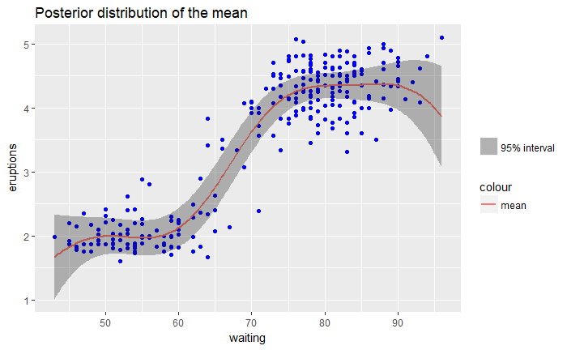

```r
ggplot() +
  geom_point(aes(x = waiting, y = eruptions), col = "blue", data = faithful) +
  geom_line(aes(x = xs, y = f, colour = "mean"), size = 1, data = res5) +
  geom_ribbon(aes(x = xs, ymin = low95, ymax = up95, fill = "95% interval"), alpha = 0.3, data = res5) +
  scale_fill_manual("", values="grey12") +
  labs(title = "Posterior distribution of the mean")
```

Back to Index

## Parameter Estimation

As we saw in the previous section, the choice of hyperparameters (for the squared exponential case, the length scale $\ell$) effects the properties of the resulting function. Rather than pick a specific value for the hyperparameter, we can specify the model in a hierarchical manner—just like we did in the linear case.

For example, in the squared exponential setting, we could specify our model as

$$\begin{aligned}
\ell^2 \sim& \mbox{Inv-Gamma}(a_\ell, b_\ell)\\
\alpha^2 \sim& \mbox{Inv-Gamma}(a_\alpha, b_\alpha)\\
\sigma^2 \sim& \mbox{Inv-Gamma}(a_\sigma, b_\sigma)\\
k(x,x') =& \alpha^2\exp\left\{-\frac{1}{2\ell^2}|x-x'|^2\right\}+\sigma^2\delta_{x-x'}\\
y|X \sim& N(0,\tilde{K})
\end{aligned}$$
where $K$ is the covariance function evaluated at the input locations $X$. Note that we have integrated out $f$ and placed our prior directly on $y$, incorporating the Gaussian likelihood into the covariance. We can then infer the posterior distribution over $\ell$ using Bayes’ Law:

$$p(\ell|y,X) = \frac{p(y|X,\ell)p(\ell)}{\int_0^\infty p(y|X,\ell)p(\ell)d\ell}$$

Unfortunately, we typically do not have an analytical form for this posterior, so we must resort to either optimization, or MCMC-based inference.

### Optimization

In practice, a common approach is to find the ML estimate for the hyperparameters. Let’s assume a generic setting, where the log likelihood is parametrized by some vector of parameters $\theta$. The log likelihood is given by

$$log p(y|X,\theta) = -\frac{1}{2}y^TK^{-1}y - \frac{1}{2}\log|K|-\frac{n}{2}\log 2 \pi$$

Taking partial derivatives, we see that

$$\begin{aligned}\frac{\partial}{d\partial \theta_j} \log p(y|X,\theta) =& \frac{1}{2}y^TK^{-1}\frac{\partial K}{\partial \theta_j} K^{-1}y - \frac{1}{2}\mbox{tr}\left(K^{-1}\frac{\partial K}{\partial \theta_j}\right)\\
=& \frac{1}{2}\mbox{tr}\left((\alpha \alpha^T - K^{-1})\frac{\delta K}{\delta \theta_j}\right)\end{aligned}$$
where $\alpha = K^{-1}y$. We can use these partial derivatives to find the ML estimate of $\theta$, using a gradient-based optimization method

### Exercise 6

*Calculate the appropriate derivatives for the one-dimensional, squared exponential case used for the dataset. Use these gradient to find the optimizing value of $\ell^2$, $\alpha^2$ and $\sigma^2$. Plot the resulting fit.*

### Exercise 7

*Repeat the previous exercise, but this time only use the first 10 data points from the faithful dataset. Repeat the optimization several times, using different initializations/random seeds. You will likely see widely different results – sometimes $\ell$ is big, sometimes $\sigma^2$ is big. Why is this? Discuss why this is a problem here, but wasn’t in the previous setting. You may find it helpful to look at the corresponding scatter plot, or plot the log likelihood for certain values of $\sigma^2$ and $\ell$.*

### MCMC

Optimization is typically pretty quick, which is why it is commonly used in practice. However, we have no guarantee that our optimization surface is convex. An alternative approach is to sample from the posterior distribution over our hyperparameters.

### Exercise 8

*Since the posterior is non-conjugate, we can’t use a Gibbs sampler. We won’t go into the details of appropriate sampling methods since this isn’t an MCMC course, but we will explore using black-box samplers. In the R folder, there are three files: `faithful\_data.R`, `gp\_regression.stan` and `run\_gp\_regression.R`. Use these to sample from the model and produce 95% credible intervals for $\alpha$, $\ell$ and $\sigma$, and 95% predictive intervals for $t$. Go through the code and make sure you understand what is going on.*

### Exercise 9

*Let’s now look at a dataset with multiple predictors. Download the dataset weather.csv – this contains latitude and longitude data for 147 weather stations, plus a response ``temperature’’, which is the difference between the forecasted and actual temperature for each station.*

*How should we extend our kernel to multiple dimensions? (There is more than one option here). Should we use the same lengthscale for latitude and longitude? Construct an appropriate parametrized kernel, and learn the parameters either via optimization or using MCMC by editing the Stan code (Note: If you go for the stan code, you will need to implement your new kernel).*

*Using an appropriate visualization tool, plot the mean function (try imshow or contourf in matlab or matplotlib (for python), or image or filled.contour for R).